# Creating images with R

with a little bit of magick

Sophia Zou

13/03/24

## Project requirements

I’ve set up a repository named *stats220* on my existing GitHub account. It’s set to public visibility, so anyone with the link can check it out. Inside, I’ve added a README file in Markdown format, laying out my project ideas and goals in a user-friendly way, also enhanced the appeal for viewers to visit the meme files I’ve created by adding some emojis..

Here are the links:

> Repository: [stats220](https://github.com/mzou791/STATS-220-2024?tab=readme-ov-file)

> Website: [stats220 GitHub Pages](https://mzou791.github.io/STATS-220-2024/)

Below is a screenshot of my project folder path on my computer:

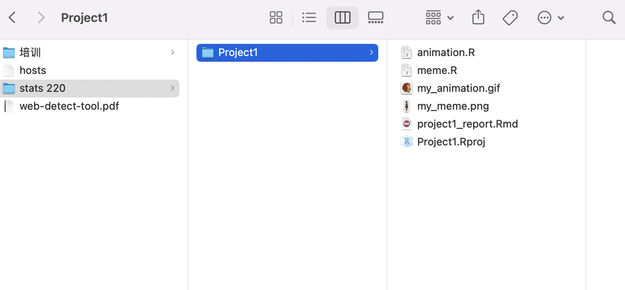

## My meme

My meme is about a perplexed monkey. It can be used anytime you’re assigned a task but you have no clue what it’s about.

I added suitable text to these images, tailored to their characteristics, and in the meme, I pieced them together. I adjusted the sizes, selecting prominent fonts and colors.

[figure not shown]

```r
library(magick)
you_image <- image_read("https://static.vecteezy.com/system/resources/previews/012/721/532/original/awkward-look-monkey-puppet-icon-free-vector.jpg")%>%
  image_scale(200)%>%
  image_annotate(text = "You?",
                 color = "yellow",
                 size = 48,
                 font = "mono",
                 gravity = "south")

huh_image <- image_read("https://i.imgflip.com/4jkbsq.png")%>%
  image_scale(200)%>%
  image_annotate(text = "Huh...",
                 color = "yellow",
                 size = 48,
                 font = "mono",
                 gravity = "south")

me_image <- image_read("https://cdn170.picsart.com/upscale-228465789059212.png?r1024x1024")%>%
  image_scale(200)%>%
  image_annotate(text = "Me?",
                 color = "yellow",
                 size = 48,
                 font = "mono",
                 gravity = "south")
what_image <- image_read("https://ih0.redbubble.net/image.4741986117.8515/raf,360x360,075,t,fafafa:ca443f4786.jpg")%>%
  image_scale(200)%>%
  image_annotate(text = "What?",
                 color = "yellow",
                 size = 48,
                 font = "mono",
                 gravity = "south")

first_line <- c(you_image) %>%
  image_append()

second_line <- c(huh_image) %>%
  image_append()

third_line <- c(me_image) %>%
  image_append()

final_line <- c(what_image) %>%
  image_append()

c(first_line, second_line, third_line,final_line) %>%
  image_append(stack = TRUE)%>%
  image_write("my_meme.png")
```

[figure not shown]

```r
library(magick)
# text inside the meme
gif_text <- c("You?", "Huh..", "Me?", "What?")

#first frame - change the size of the meme
you_frame1 <- you_image <- image_read("https://static.vecteezy.com/system/resources/previews/012/721/532/original/awkward-look-monkey-puppet-icon-free-vector.jpg")%>%
  image_scale(170)%>%
  image_annotate(gif_text[1],
                 color = "yellow",
                 size = 36,
                 font = "mono",
                 gravity = "south")
you_frame2 <- you_image <- image_read("https://static.vecteezy.com/system/resources/previews/012/721/532/original/awkward-look-monkey-puppet-icon-free-vector.jpg")%>%
  image_scale(170)%>%
  image_annotate(gif_text[1],
                 color = "yellow",
                 size = 40,
                 font = "mono",
                 gravity = "south")
you_frame3 <- you_image <- image_read("https://static.vecteezy.com/system/resources/previews/012/721/532/original/awkward-look-monkey-puppet-icon-free-vector.jpg")%>%
  image_scale(170)%>%
  image_annotate(gif_text[1],
                 color = "yellow",
                 size = 48,
                 font = "mono",
                 gravity = "south")

#second frame - change the size of the meme and resize it cause the front is very bottom
huh_frame1 <- image_read("https://i.imgflip.com/4jkbsq.png")%>%
  image_resize("200x180!")%>%
  image_annotate(gif_text[2],
                 color = "yellow",
                 size = 36,
                 font = "mono",
                 gravity = "south")
huh_frame2 <- image_read("https://i.imgflip.com/4jkbsq.png")%>%
  image_resize("200x180!")%>%
  image_annotate(gif_text[2],
                 color = "yellow",
                 size = 40,
                 font = "mono",
                 gravity = "south")
huh_frame3 <- image_read("https://i.imgflip.com/4jkbsq.png")%>%
  image_resize("200x180!")%>%
  image_annotate(gif_text[2],
                 color = "yellow",
                 size = 48,
                 font = "mono",
                 gravity = "south")

#third_frame
me_frame1 <- image_read("https://cdn170.picsart.com/upscale-228465789059212.png?r1024x1024")%>%
  image_scale(200)%>%
  image_annotate(gif_text[3],
                 color = "yellow",
                 size = 36,
                 font = "mono",
                 gravity = "south")
me_frame2 <- image_read("https://cdn170.picsart.com/upscale-228465789059212.png?r1024x1024")%>%
  image_scale(200)%>%
  image_annotate(gif_text[3],
                 color = "yellow",
                 size = 40,
                 font = "mono",
                 gravity = "south")
me_frame3 <- image_read("https://cdn170.picsart.com/upscale-228465789059212.png?r1024x1024")%>%
  image_scale(200)%>%
  image_annotate(gif_text[3],
                 color = "yellow",
                 size = 48,
                 font = "mono",
                 gravity = "south")

#last_frame
what_frame1 <- image_read("https://ih0.redbubble.net/image.4741986117.8515/raf,360x360,075,t,fafafa:ca443f4786.jpg")%>%
  image_resize("200x180!")%>%
  image_annotate(gif_text[4],
                 color = "yellow",
                 size = 36,
                 font = "mono",
                 gravity = "south")
what_frame2 <- image_read("https://ih0.redbubble.net/image.4741986117.8515/raf,360x360,075,t,fafafa:ca443f4786.jpg")%>%
  image_resize("200x180!")%>%
  image_annotate(gif_text[4],
                 color = "yellow",
                 size = 40,
                 font = "mono",
                 gravity = "south")
what_frame3 <- image_read("https://ih0.redbubble.net/image.4741986117.8515/raf,360x360,075,t,fafafa:ca443f4786.jpg")%>%
  image_resize("200x180!")%>%
  image_annotate(gif_text[4],
                 color = "yellow",
                 size = 48,
                 font = "mono",
                 gravity = "south")
#sort it.
gif_frames <- c(you_frame1,you_frame2,you_frame3, huh_frame1,huh_frame2,huh_frame3,me_frame1,me_frame2,me_frame3,what_frame1,what_frame2,what_frame3)

#run it, change the fps make it faster
image_animate(gif_frames, fps = 2)%>%
  image_write("my_animation.gif")
```

## Learning reflection

In Module 1, I learned how to create an emoji pack using R, which is incredible. It demonstrates the power of modern technology. I want to explore CSS design further because I’ve discovered that although CSS seems simple, it can create many vibrant web pages. Additionally, I’m interested in delving deeper into fonts within the emoji pack, such as studying font backgrounds and styles.